# Module 3: Excel & Data Analytics (7.5 Hours)

From Raw Data to Business Insights

Author

Dr Aniruddha Bonnerjee

Abstract

Session 4: Data Visualization - the art of communicating data

# Session 4: Visualization & Capstone Project

### Duration: 2 hours

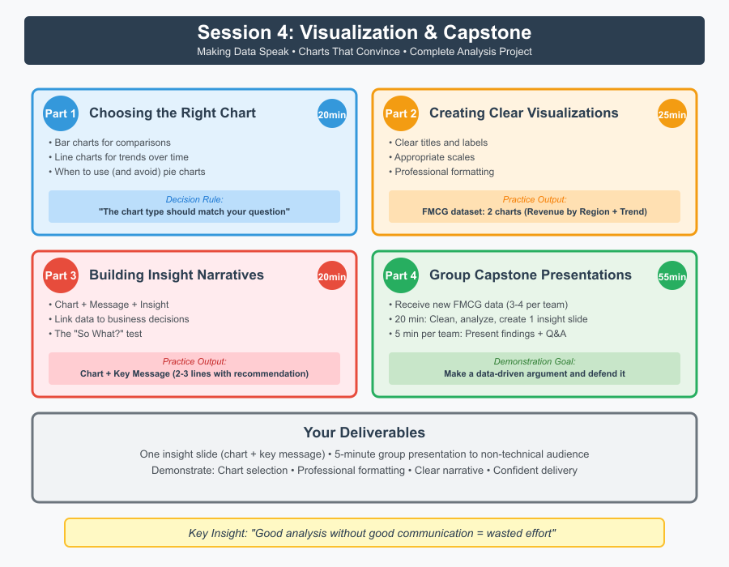

## Session Objective

By the end of this session, you will be able to: - Choose the right chart type for different business questions - Create clear, professional visualizations in Excel - Build insight narratives that connect data to decisions - Present findings effectively to non-technical audiences - Avoid common visualization mistakes that mislead or confuse - Execute a complete analysis project from raw data to presentation - Defend your analysis and recommendations under questioning

## Why Visualization Matters

You’ve cleaned data. You’ve analyzed it with formulas and pivot tables. You’ve found patterns.

**Now comes the hardest part: making other people care.**

Most business decisions aren’t made by data analysts. They’re made by managers, executives, and teams who: - Don’t have time to read spreadsheets - Don’t know what a pivot table is - Need to understand your point in 30 seconds - Want to know: **“So what should I do?”**

**Visualization is translation.** You’re translating numbers into a language everyone speaks: visual patterns.

**The stakes:** - A well-designed chart can communicate in 5 seconds what would take 5 minutes to explain in words - A poorly-designed chart can obscure the truth, mislead decision-makers, or worse—make them ignore you entirely

**Today’s goal:** Learn to make data speak clearly, honestly, and persuasively.

## Today’s Structure

### Part 1-3: Learn Visualization (65 minutes)

- Choosing chart types
- Creating clear visualizations
- Building insight narratives

## Part 1: Choosing the Right Chart Type (20 minutes)

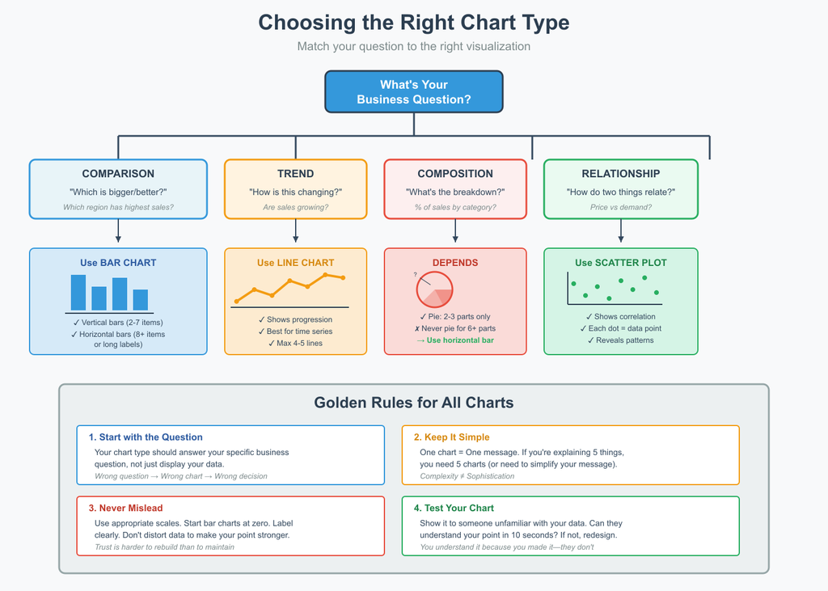

### The Cardinal Rule

**Your chart type should match the question you’re answering.**

Not the data you have. Not the chart you think looks pretty. **The question.**

#### 1. Comparison - “Which is bigger/better?”

**Examples:** - Which region has highest sales? - Which product is most profitable? - How do channels compare?

**Best chart:** Bar chart (horizontal or vertical)

**Why it works:** Humans are excellent at comparing bar lengths. We can instantly see “this is bigger than that.”

**Choose vertical bars when:** - Few categories (2-7) - Category names are short

**Choose horizontal bars when:** - Many categories (8+) - Long category names (e.g., “Beauty & Personal Care”) - Easier to read left-to-right

#### 2. Trend Over Time - “How is this changing?”

**Examples:** - Are sales growing or declining? - What’s the seasonal pattern? - Is performance improving?

**Best chart:** Line chart

**Why it works:** Lines naturally show direction (up, down, flat). Our eyes follow the path and see the story.

**Line chart rules:** - X-axis = Time (always!) - Y-axis = The metric (sales, profit, etc.) - Max 4-5 lines on one chart (more = spaghetti)

#### 3. Composition - “What’s the breakdown?”

**Examples:** - What % of sales comes from each category? - How is the total divided? - What’s the market share?

**Best chart:** - **Pie chart** (use sparingly! Only 2-3 slices) - **Stacked bar** (better for 4+ categories) - **Horizontal bar** (often clearest option)

**Why pie charts fail:** - Hard to compare similar-sized slices - Human eyes are bad at comparing angles - Become unreadable with 6+ slices

**When to use pie charts:** - 2-3 categories maximum - Showing simple part-of-whole - Exact percentages don’t matter much

**Better alternative:** Horizontal bar chart sorted by size. Easier to read, easier to compare.

### Chart Type Decision Tree

```
What's your question?
│
├─ Comparing categories?
│   ├─ Few categories (2-7)? → Vertical bar chart
│   └─ Many categories (8+) or long names? → Horizontal bar chart
│
├─ Showing change over time?
│   ├─ One metric? → Single line chart
│   └─ Multiple metrics? → Multiple lines (max 4-5)
│
├─ Showing part-of-whole?
│   ├─ 2-3 parts? → Pie chart (acceptable)
│   ├─ 4-6 parts? → Stacked bar OR horizontal bar
│   └─ 7+ parts? → Never pie! Use horizontal bar chart
│
└─ Showing relationship between 2 variables?
    → Scatter plot
```

### Practice: Match the Question to the Chart

For each business question, identify the best chart type:

1. “Which product category generated the most revenue in Q2-2024?”
2. “How has Beverages revenue changed over the past 6 quarters?”
3. “What percentage of total revenue comes from the North region?”
4. “How do the 5 regions compare in terms of average transaction value?”
5. “Is there a relationship between units sold and market share?”

### When NOT to Use Certain Charts

**Never use:** - ❌ 3D charts (distort perception, look dated) - ❌ Pie charts with 7+ slices (unreadable) - ❌ Multiple pie charts side-by-side (use grouped bars instead) - ❌ Radar/spider charts (almost always confusing) - ❌ Dual-axis charts with vastly different scales (misleading)

**Use sparingly:** - ⚠️ Pie charts (only 2-3 slices, simple message) - ⚠️ Stacked bars (hard to compare middle segments) - ⚠️ Area charts (similar issues to stacked bars)

## Part 2: Creating Clear Visualizations (25 minutes)

### The Three Elements of a Good Chart

Every effective chart has three components:

#### 1. A Clear Title (States the Insight!)

**❌ Bad:** “Regional Sales”  
**✅ Good:** “North Region Leads with 32% of Total Sales”

**The title should tell the story, not just label the topic.**

Think of it as a headline: What’s the main finding?

#### 2. Proper Labels

**Must have:** - Y-axis label (what’s being measured) - Units (₹, %, thousands, millions) - Data labels (if few data points < 10) - Legend (if multiple data series)

**Example:**

```
Y-axis: "Revenue (₹ Millions)"
Not just: "Revenue"
Not just: "Millions"
```

#### 3. Appropriate Scale

**Rules:** - Y-axis should usually start at zero for bar charts - Avoid broken axes unless clearly labeled - Use consistent scales when comparing charts - Don’t exaggerate differences by manipulating scale

**Example of misleading scale:**

```
❌ Bad: Y-axis from ₹4.8M to ₹5.2M
   Makes 5% difference look like 500% difference

✅ Good: Y-axis from ₹0 to ₹6M
   Shows true proportional difference
```

### Chart Anatomy Checklist

Before showing your chart to anyone, verify:

- Title clearly states the main finding
- Y-axis has a label and units
- X-axis has a label (if not obvious)
- Legend is present (if multiple data series)
- **Data labels on bars/points** - CRITICAL for accessibility
  - Never rely on color alone to convey information
  - Always label your data points with values
  - This helps everyone, especially those with color vision deficiency
- **Colors are accessible and distinguishable**
  - **NEVER use red-green combinations** (8% of men have red-green color blindness)
  - Use high contrast combinations (blue-orange, blue-yellow)
  - Test in grayscale: Can you still tell categories apart?
  - Consider patterns/textures in addition to colors
- Chart is not cluttered
  - Remove gridlines if not needed
  - Remove chart border
  - Simplify where possible
- Source/date is noted (optional but professional)

### Building Your First Chart: Revenue by Region

**Using the FMCG dataset (you’ll receive this for the capstone):**

#### Step 1: Prepare Your Data

Option A: From a Pivot Table 1. Create a pivot table: Regions (rows) × Sum of Revenue (values) 2. Copy the result 3. Paste as values in a clean area

Option B: Manual Summary 1. Create a simple two-column table 2. Column A: Region names 3. Column B: Revenue values

#### Step 2: Select Data and Insert Chart

1. Select your data (including labels)
2. **Insert** tab → **Charts** group
3. Choose **Column Chart** or **Bar Chart**
4. Click on the specific chart subtype you want

**Recommendation:** Start with simple 2-D charts, not 3-D!

#### Step 3: Format for Clarity

**Add/Edit Chart Title:** 1. Click on chart title 2. Type: “North and South Regions Drive 55% of Revenue” (or whatever your actual finding is!)

**Add Axis Titles:** 1. Chart Design tab → Add Chart Element → Axis Titles 2. Primary Vertical → Type: “Revenue (₹ Millions)” 3. Primary Horizontal → Usually not needed for region names

**Format Data Labels (ESSENTIAL for Accessibility):** 1. Click on data bars 2. Chart Design → Add Chart Element → Data Labels → Outside End 3. Right-click data labels → Format Data Labels 4. Choose: Currency, 1 decimal place

**Why this matters:** About 8% of men have red-green color blindness. If you use red and green bars without labels, they literally cannot tell which is which. **Always label your data!**

**Remove Clutter:** 1. Click on gridlines → Press Delete (or make them light gray) 2. Click on chart border → Format → No Line 3. Click on legend → Delete if obvious from labels

**Adjust Colors (With Accessibility in Mind):** 1. Click on data series → Format Data Series 2. Fill & Line → Solid Fill → Choose from accessible palette 3. **AVOID red-green combinations** (8% of men are red-green colorblind) 4. **USE blue-orange, blue-yellow, or purple-yellow** (safe for all viewers) 5. **Test in grayscale:** Can you still distinguish categories? 6. Use your company/school colors if they’re accessible 7. **Remember: Always add data labels so color isn’t the only differentiator**

#### Step 4: Final Polish

**Check the scale:** - Does Y-axis start at zero? (It should for bar charts) - Is the range appropriate?

**Check readability:** - Can you read all text at 12pt minimum? - Is everything aligned and clean?

**Test the message:** - Can someone understand this in 5 seconds? - Is the main finding obvious?

### Practice Task 1: Category Performance Chart

Using your **cleaned Company Sales Performance** data from Sessions 1-3:

**Create a bar chart that shows:** - **Question:** Which product category has the highest revenue? - **Data:** Product_Category (X-axis) × Total Sales (Y-axis) - **Title:** State your finding (which category wins?) - **Sort:** Highest to lowest revenue - **Format:** Clean, professional, clear labels

**Time limit:** 10 minutes

### Practice Task 2: Quarterly Trend Chart

**Create a line chart that shows:** - **Question:** How is total revenue trending over time? - **Data:** Month or Quarter (X-axis) × Revenue (Y-axis) - **Title:** Is it growing, declining, or stable? - **Format:** - Use markers on data points - Label axes clearly - Add a trendline if appropriate (Chart Design → Add Chart Element → Trendline)

**Time limit:** 10 minutes

## Part 3: Building Insight Narratives (20 minutes)

### The Insight Formula

A complete insight has three parts:

```
CHART + MESSAGE + RECOMMENDATION = INSIGHT
```

**Chart alone:** Just data  
**Chart + Message:** Information  
**Chart + Message + Recommendation:** Actionable insight

### The Anatomy of a Strong Insight

**❌ Weak Example:** > “This chart shows sales by region. North has the highest sales.”

*(This just describes the chart. So what?)*

**✅ Strong Example:** > “North region generates ₹4.2M (32% of total revenue), outperforming all other regions. However, South region is growing fastest (18% quarter-over-quarter) and may overtake North by year-end.  
> > **Recommendation:** Increase inventory allocation to South to capitalize on growth momentum, while investigating why East and Central lag behind.”

**See the difference?** - States the pattern clearly (North leads) - Adds context (but South is growing faster) - Connects to business implications (may overtake by year-end) - Suggests concrete action (inventory allocation, investigation)

### The “So What?” Test

For every chart you create, ask three questions:

#### 1. What does the data show? (The pattern)

**Example:** “Beverages revenue spiked in Q2 and Q3 of both years.”

#### 2. Why does it matter? (The implication)

**Example:** “This indicates strong seasonality—summer drives beverage sales.”

#### 3. What should we do? (The recommendation)

**Example:** “Plan inventory and marketing budgets to peak in Q2-Q3. Explore ways to boost off-season sales with promotions or new products.”

**If you can’t answer all three, your chart isn’t ready to present.**

### Writing Insight Narratives: Templates

#### Template 1: Highlight + Context + Action

> “[Metric] shows [pattern]. This is significant because [reason]. We should [action].”

**Example:** > “Online channel generates 45% of total revenue with an average transaction value of ₹68,000—significantly higher than Retail (₹42,000). This is significant because online has lower operational costs while delivering higher-value sales. We should shift 20% of marketing budget from retail to digital channels and optimize the online customer experience.”

#### Template 2: Problem + Evidence + Solution

> “We’re facing [problem]. As the data shows, [evidence from chart]. To address this, I recommend [solution].”

**Example:** > “We’re facing declining market share in the West region. As the data shows, West region revenue dropped 22% quarter-over-quarter while competitors grew 15% in the same market. To address this, I recommend: (1) competitive pricing audit within 1 week, (2) customer exit interviews to understand churn, (3) aggressive promotional campaign for Q4.”

#### Template 3: Opportunity + Proof + Next Steps

> “There’s an opportunity to [opportunity]. The data reveals [proof]. Next steps: [specific actions].”

**Example:** > “There’s an opportunity to increase B2B penetration. The data reveals B2B customers have 3x higher average transaction value (₹95K vs ₹32K) but represent only 15% of our customer base. Next steps: (1) Hire dedicated B2B sales team, (2) Develop enterprise pricing packages, (3) Attend 3 industry trade shows in Q1 2025.”

### Practice: Build Your Insight Slide

Choose ONE of these business questions and create a complete insight slide:

#### Option A: Product Performance

- **Question:** Which product category should we prioritize for growth investment?
- Create appropriate chart
- Write 2-3 sentence narrative
- Include specific recommendation

#### Option B: Regional Strategy

- **Question:** Should we expand into underperforming regions or double down on strong ones?
- Create comparison chart
- Analyze trade-offs
- Make a clear recommendation with rationale

#### Option C: Trend Analysis

- **Question:** What’s our biggest risk or opportunity based on recent trends?
- Create trend chart (line or bar)
- Identify the pattern
- Suggest proactive measures

**Your slide should contain:** 1. One clear, well-formatted chart 2. A title that states your finding 3. 2-3 sentences of narrative (pattern + implication + recommendation) 4. Professional formatting (consistent fonts, aligned elements)

## Part 4: Group Capstone Presentations (55 minutes)

### The Challenge

**You are now business analysts.**

You’ll receive a new dataset: **FMCG Performance Data** containing: - 600 records of FMCG sales - 5 product categories (Biscuits, Beverages, Personal Care, Snacks, Dairy) - 3 brands per category - 5 regions (North, South, East, West, Central) - 6 quarters of data (Q1-2023 to Q2-2024) - Variables: Units Sold, Revenue, Market Share %

**This dataset is clean** (no duplicates, no missing values), but you’ve never seen it before.

### Your Mission (Teams of 3-4)

**Time: 20 minutes total**

**Minute 0-5: Explore & Plan** - Open the dataset - Understand what you have - Decide on ONE business question to answer - Assign roles: Who analyzes? Who creates chart? Who writes narrative?

**Minute 5-15: Analyze** - Build necessary pivot tables or use formulas - Identify the key pattern/insight - Create ONE professional chart

**Minute 15-20: Build Slide** - Create one PowerPoint or Excel slide - Include: Chart + Title + Key Message (2-3 sentences) - Make it presentation-ready

**Minute 20+: Present** (5 minutes per group) - Show your slide - State your finding - Explain why it matters - Make your recommendation - Handle Q&A

### Suggested Business Questions

Choose ONE to focus on:

1. **Market Opportunity:** Which region has the most growth potential?
2. **Product Strategy:** Which category should receive increased investment?
3. **Brand Performance:** Which brands are winning/losing market share?
4. **Seasonal Planning:** What seasonal patterns exist? How should we prepare?
5. **Performance Gap:** Where is the biggest gap between potential and actual performance?

**Don’t try to answer everything!** Pick ONE question and answer it well.

### Group Roles

Assign these roles quickly:

**Analyst (1-2 people):** - Explore data - Create pivot tables - Identify patterns

**Designer (1 person):** - Create the chart - Format professionally - Ensure clarity

**Storyteller (1 person):** - Write the narrative - Prepare talking points - Lead the presentation

**Everyone:** Practice the 5-minute presentation!

### Presentation Structure (5 minutes)

**Slide 1: The Insight (30 seconds)** - Show your chart - State your main finding in one sentence

**Q&A (1.5 minutes)** - Answer questions from peers and instructor - Defend your analysis - Clarify your recommendations

### Presentation Tips

**Do:** - ✓ Start with the conclusion (“North region has the highest growth potential”) - ✓ Speak clearly and confidently - ✓ Point to specific parts of your chart - ✓ Connect findings to business decisions - ✓ Acknowledge limitations (“We’d need customer feedback data to confirm…”)

**Don’t:** - ✗ Apologize (“Sorry this isn’t perfect…”) - ✗ Read your slide verbatim - ✗ Get lost in technical details - ✗ Present without practicing first - ✗ Ignore questions or get defensive

### Peer Feedback Framework

After each presentation, the class will evaluate using these criteria:

**Chart Quality (1-5)** - ✓ Was the chart type appropriate? - ✓ Was it easy to read and understand? - ✓ Did it clearly support the message?

**Insight Quality (1-5)** - ✓ Was the finding clear and specific? - ✓ Was the “why it matters” convincing? - ✓ Was the recommendation actionable?

**Presentation Delivery (1-5)** - ✓ Did they speak confidently and clearly? - ✓ Did they handle questions well? - ✓ Was it engaging and persuasive?

### What Success Looks Like

**A successful presentation:** 1. Answers a specific business question 2. Uses an appropriate, well-formatted chart 3. Provides context and interpretation 4. Makes a clear, actionable recommendation 5. Handles questions with confidence 6. Stays within 5 minutes

**Remember:** This simulates real work. In your career, you’ll regularly: - Receive new data with short deadlines - Need to find insights quickly - Present to stakeholders who don’t have context - Defend your recommendations

**Today is practice for that reality.**

## Common Visualization Mistakes & Fixes

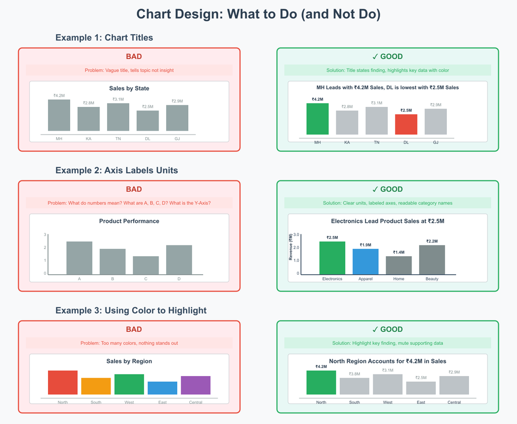

### Mistake 1: Wrong Chart Type

**❌ Problem:** Using a pie chart with 8 slices - Hard to compare slice sizes - Labels overlap - Unreadable

**✅ Fix:** Use horizontal bar chart, sorted by size

**❌ Problem:** Using a line chart for categories - Lines imply continuity/trend - Categories like “Products” aren’t sequential

**✅ Fix:** Use bar chart for categorical comparisons

### Mistake 2: Misleading Scales

**❌ Problem:** Starting Y-axis at non-zero to exaggerate differences - Makes small differences look huge - Misleading to viewers

**✅ Fix:** - Start at zero for bar charts - If using non-zero start, clearly label it: “Scale begins at ₹4M”

**❌ Problem:** Using inconsistent scales across charts - Can’t compare charts side-by-side - Leads to wrong conclusions

**✅ Fix:** Use same scale for all comparison charts

### Mistake 3: Too Much Information

**❌ Problem:** Showing 15 data series on one line chart - “Spaghetti chart” - Impossible to read - No clear message

**✅ Fix:** - Show top 3-5 series - Group others as “Other” - Or create multiple charts

**❌ Problem:** Including every column from your dataset - Overwhelming - No clear focus

**✅ Fix:** Choose 1-2 metrics that answer your specific question

### Mistake 4: Poor Visual Hierarchy

**❌ Problem:** All text same size, all bars same color - Nothing stands out - Eye doesn’t know where to look

**✅ Fix:** - Highlight key data with color - Make title larger/bold - Use contrast strategically

### Mistake 5: No Context

**❌ Problem:** Chart titled “Sales” - Sales of what? When? Compared to what?

**✅ Fix:** “Q2 2024 Sales Grew 15% vs Q1, Driven by Beverages” - What happened - When - Why it matters

## Your Final Deliverables

By the end of this session, you should have:

### ✓ Individual Practice Charts (from Part 1-3)

At least two professional charts: 1. Bar chart (comparison) 2. Line chart (trend)

Each with: - Clear title stating the insight - Proper labels and units - Professional formatting - Brief narrative (2-3 sentences)

### ✓ Group Capstone Slide

One complete insight slide containing: - Professional chart from FMCG data - Title stating your key finding - 2-3 sentence narrative (pattern + implication + recommendation) - Proper formatting and design

### ✓ 5-Minute Group Presentation

Demonstrate ability to: - Communicate data insights clearly - Connect findings to business decisions - Make actionable recommendations - Handle questions confidently - Work effectively in a team

## Excel Chart Tips & Tricks

### Quick Chart Creation

**Fastest way to create a chart:** 1. Select your data 2. Press **Alt + F1** → Creates default chart instantly 3. Or **F11** → Creates chart in new sheet

### Chart Formatting Shortcuts

**Essential shortcuts:** - **Ctrl + 1** → Opens Format pane (works on any selected chart element) - **Double-click** any chart element → Opens formatting options - **F4** → Repeat last action (great for formatting multiple elements)

**Copy chart formatting:** 1. Right-click source chart → **Copy** 2. Right-click target chart → **Paste Special** → **Formats**

### Professional Color Palettes

**CRITICAL: Color Blindness Affects 8-10% of Men and 0.5% of Women**

Approximately 1 in 12 men and 1 in 200 women have some form of color vision deficiency. The most common is red-green color blindness.

**Golden Rules for Accessible Colors:**

1. **NEVER use red-green combinations**
   - ❌ Red for negative, green for positive (many people can’t distinguish!)
   - ✅ Blue for negative, orange for positive
   - ✅ Or use blue + yellow, or blue + brown
2. **Use high contrast**
   - Dark vs light, not similar shades
   - Test: View your chart in grayscale—can you still tell categories apart?
3. **Always label data points**
   - Never rely on color alone
   - Add text labels showing actual values
   - This helps everyone, not just colorblind viewers
4. **Consider patterns in addition to colors**
   - Striped bars vs solid bars
   - Dotted lines vs solid lines
   - Different marker shapes (circles, squares, triangles)

**Recommended Color Palettes:**

**Safe Palette 1 (Blue-Orange):** - Primary: #2E5090 (dark blue) - Secondary: #E67E22 (orange) - Neutral: #7F8C8D (gray) - Highlight: #F39C12 (yellow-orange)

**Safe Palette 2 (Blue-Brown):** - Primary: #3498DB (bright blue) - Secondary: #8B4513 (brown) - Neutral: #95A5A6 (light gray) - Highlight: #F1C40F (yellow)

**Safe Palette 3 (Purple-Yellow):** - Primary: #9B59B6 (purple) - Secondary: #F1C40F (yellow) - Neutral: #34495E (dark gray) - Highlight: #E67E22 (orange)

**Colors to AVOID Together:** - ❌ Red + Green (most common color blindness) - ❌ Blue + Purple (hard to distinguish for some) - ❌ Green + Brown (can look similar) - ❌ Light colors on light backgrounds

**Best Practice Workflow:** 1. Create your chart 2. Add data labels to all bars/points 3. Choose accessible color palette 4. **Test in grayscale:** Insert → Screenshot → Paste → Format Picture → Color → Grayscale 5. Can you still tell categories apart? If yes, you’re good! 6. If no, adjust colors or add patterns

### Advanced Chart Tricks

**1. Remove Chart Junk**

Delete chart border: - Select chart area → Format → Shape Outline → No Outline

Simplify gridlines: - Make them light gray (#E0E0E0) - Or remove minor gridlines entirely

**2. Add Data Labels Selectively**

Don’t label every point if you have 20+ data points.

Instead: - Label only min, max, or key values - Use callout boxes for important points - Add annotations with text boxes

**3. Customize Axis Scales**

Right-click axis → Format Axis - Set min/max bounds to focus on relevant range - Adjust intervals for cleaner appearance - Change to logarithmic scale if needed

**4. Create Dynamic Titles**

Make your chart title update automatically: 1. Click chart title 2. In formula bar, type `=` then click a cell 3. Title now updates when that cell changes

**Example:** Link title to a cell that says “Q2 2024 Performance”

## Key Takeaways

✓ **Chart type must match your question** - Comparison? Trend? Composition?

✓ **Clarity beats fancy every time** - Simple, clean, readable charts win

✓ **A chart without a message is incomplete** - Always interpret, never just display

✓ **Your audience doesn’t think like you** - Explain context, highlight insights, suggest actions

✓ **Practice makes perfect** - The more charts you make, the better your instincts become

✓ **Presenting is a skill** - Confidence, clarity, and storytelling matter as much as the data

✓ **Real work has deadlines** - The capstone simulates real business pressure

## Module 3: Complete!

**Congratulations!** You’ve completed Module 3: Excel & Data Analytics.

### Your Journey:

**Session 1:** Data Understanding + Cleaning Fundamentals - ✓ Befriended messy data - ✓ Removed duplicates and handled missing values - ✓ Created status flags with IF functions - ✓ Learned to question data quality

**Session 2:** Excel Formulas + Table Lookups - ✓ Mastered SUMIF, COUNTIF, AVERAGEIF - ✓ Used VLOOKUP/XLOOKUP to connect data sources - ✓ Enriched dataset with profit calculations - ✓ Built comprehensive summary tables

**Session 3:** Mastering Pivot Tables - ✓ Created instant summaries from thousands of rows - ✓ Built multi-dimensional analysis - ✓ Extracted business insights from patterns - ✓ Learned to think in questions, not features

**Session 4:** Visualization & Capstone - ✓ Chose appropriate chart types - ✓ Created professional visualizations - ✓ Built insight narratives - ✓ Presented findings under time pressure

### You Can Now:

**Technical Skills:** - Clean and prepare messy data - Use essential Excel functions (IF, SUMIF, COUNTIF, AVERAGEIF) - Combine data from multiple sources (VLOOKUP/XLOOKUP) - Create pivot tables for instant analysis - Build professional visualizations - Present data insights convincingly

**Analytical Thinking:** - Question data quality and limitations - Translate business questions into data questions - Identify patterns and extract insights - Connect findings to business decisions - Communicate complex information simply

**This is the foundation of every analytics role, from entry-level analyst to Chief Data Officer.**

## Next Steps: Building Your Portfolio

**1. Practice on Real Datasets** - Kaggle (kaggle.com/datasets) - Government open data portals - Your own organization’s data - Personal projects (budget tracking, fitness data, etc.)

**2. Build a Portfolio of Insights**

Create 3-5 strong examples: - Each with a business question - Clean → Analyze → Visualize → Insight - Professional formatting - Clear narratives

**3. Share Your Work** - LinkedIn posts with insights - GitHub repository with analysis files - Personal website or blog - Include in job applications

**4. Keep Learning**

**Natural next steps:** - **SQL** - Query databases directly - **Python/R** - Advanced analysis and automation - **Tableau/Power BI** - Interactive dashboards - **Statistics** - Deeper analytical methods

**But remember:** Tools change. Technologies evolve. But the ability to find truth in data and communicate it clearly? **That’s timeless.**

## Questions to Reflect On

After completing this module:

1. What surprised you most about working with data?
2. Which skill (cleaning, formulas, pivots, visualization) do you want to practice more?
3. How would you use these skills in your current or future role?
4. What’s one dataset from your life or work you’d like to analyze?
5. How has your view of “data analysis” changed since Session 1?

## Final Words

**Data analysis isn’t about being a math genius or a computer expert.**

It’s about: - **Curiosity** - Asking good questions - **Rigor** - Being thorough and honest - **Clarity** - Making complex things simple - **Impact** - Connecting insights to action

**You now have these skills. Use them wisely.**

Every business decision should be informed by data. Every claim should be verified. Every recommendation should have evidence.

**Be the person who brings clarity to confusion.**  
**Be the analyst who turns numbers into narratives.**  
**Be the voice that makes data speak truth to power.**

**Thank you for your dedication throughout Module 3.**

**Now go find insights, tell stories, and drive decisions.**

*Module 3: Excel & Data Analytics | Session 4 of 4*

**End of Module**